# Пример правильного кода

Ваш код - текст, который **много раз будет читаться** вами и вашими коллегами. Таким образом, легче один раз написать код понятно, чем сто раз его перечитывать и, возможно, разбираться в нем с нуля :-)

Для того, чтобы ваш код выглядел как английский текст, нужно соблюдать ряд правил:

- **Называйте переменные осмысленно**. Это очень сильно облегчит вам жизнь, поскольку вы сможете по названию функции понять, что она делает (не залезая в её код), а по названию переменной сможете сразу сказать, что в ней лежит.
- **Используйте комментарии**. Комментарии начинаются с решетки (#). Это куски кода, которые не исполняются программой, но позволяют внести дополнительную информацию о коде. Комментирование кода также позволит легче ориентироваться в блоках самой программы :)
- **Используйте докстрингу**. Докстринга (*Docstring*) - многострочный текст, заключенный в три кавычки (либо '''текст''', либо """текст"""). Этот текст используется для документирования, в частности, функций. В нем вы можете расписать что **делает** функция, что **принимает** на вход, что **возвращает** на выход и т.д.
- **Старайтесь соблюдать структуру**. Это особенно критично, когда вы пользуетесь Jupyter'ом. В процессе работы часто приходиться "прыгать" по ячейкам, поэтому могут возникать моменты "в 20-ой ячейке создал функцию, которую применил в 3-ей". Когда вы снова вернетесь к коду "с чистого листа", что-нибудь может поломаться :)
- **Старайтесь соблюдать PEP 8**. Его можно назвать руководством по написанию кода. PEP 8 позволяет унифицировать код, тем самым делая его более понятным. Ссылка на PEP 8 - https://www.python.org/dev/peps/pep-0008/

Помните, что программист тратит 90% времени на чтение кода :-)

## 1. Подготовка к работе

```python
# Подгружаем библиотеки

import matplotlib.pyplot as plt
import numpy as np
import pandas as pd
import seaborn as sns
```

```python
# Подготавливаем общие настройки для графиков
# Нашел параметры в интернете

sns.set(
    rc={
        "figure.figsize": (12, 8), #размер графика - 12 дюймов в ширину, 8 в длину
        "axes.titlesize": 20, #размер заголовка
        "axes.labelsize": 14, #размер подписей осей
        "xtick.labelsize": 13, #размер подписей чёрточек на x-оси
        "ytick.labelsize": 13, #размер подписей чёрточек на y-оси
    }
)

sns.set_style("whitegrid") #тема фона, белая со штриховкой
```

```python
# Создадим вспомогательную функцию

def print_lines_of_file(path_to_file, n_lines=None):
    """
    Данная вспомогательная функция принимает путь к файлу
        и выводит на печать заданное количество строк из файла.

    Параметры
    ---------
    path_to_file: путь к файлу
    n_lines: количество строк, которые нужно напечатать.
        Если этот параметр не указан, то на печать выведется весь текст построчно

    Функция возвращает None
    """
    with open(path_to_file) as check_format:

        if n_lines is None:
            # Выводим весь текст на печать
            for line in check_format:
                print(line.strip()) #.strip() убирает лишние пробелы в начале и конце строки

        else:
            # Выводим на печать n_lines строк
            for line, _ in zip(check_format, range(n_lines)):
                print(line.strip())
```

## 2. Загрузка данных

В качестве примера возьмем данные о студентах. У нас имеется следующая информация:

- Пол студента (Gender)
- Его обычный ланч (Lunch)
- Баллы по математике (Math_score)
- Баллы по чтению (Reading_score)
- Баллы по письму (Writing_score)

```python
# Проверим первые 5 строк в файле
path_to_data = "./test_data.csv"
print_lines_of_file(path_to_data, n_lines=5)
```

```
# Это тестовые данные
# В них представлена информация о студентах …
# Данные любезно предоставлены …
Gender,Lunch,Math_score,Reading_score,Writing_score
female,standard,72,72,74
```

Как мы видим, первые 3 строки необходимо пропустить.

```python
# Считываем данные
whole_students_data = pd.read_csv(path_to_data, skiprows=3)
whole_students_data.head()
```

|  | Gender | Lunch | Math_score | Reading_score | Writing_score |
| --- | --- | --- | --- | --- | --- |
| 0 | female | standard | 72 | 72 | 74 |
| 1 | female | standard | 69 | 90 | 88 |
| 2 | female | standard | 90 | 95 | 93 |
| 3 | male | free/reduced | 47 | 57 | 44 |
| 4 | male | standard | 76 | 78 | 75 |

```python
# Посмотрим размер данных
whole_students_data.shape
```

```
(596, 5)
```

```python
# Посмотрим тип переменных
whole_students_data.dtypes
```

```
Gender           object
Lunch            object
Math_score        int64
Reading_score     int64
Writing_score     int64
dtype: object
```

Все отлично!

## 3. Расчёт среднего балла

```python
# Создадим новую колонку, где будет средний балл студента по всем трём предметам

whole_students_data["Mean_score"] = (
    whole_students_data[["Math_score", "Reading_score", "Writing_score"]]
    .apply(np.mean, axis=1)
    .round(2)
)

whole_students_data.head()
```

|  | Gender | Lunch | Math_score | Reading_score | Writing_score | Mean_score |
| --- | --- | --- | --- | --- | --- | --- |
| 0 | female | standard | 72 | 72 | 74 | 72.67 |
| 1 | female | standard | 69 | 90 | 88 | 82.33 |
| 2 | female | standard | 90 | 95 | 93 | 92.67 |
| 3 | male | free/reduced | 47 | 57 | 44 | 49.33 |
| 4 | male | standard | 76 | 78 | 75 | 76.33 |

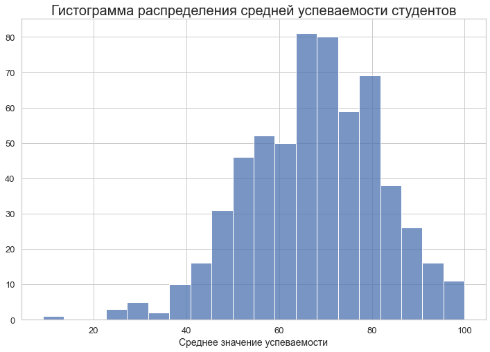

```python
# Посмотрим распределение средней успеваемости

sns.histplot(whole_students_data["Mean_score"])
plt.xlabel("Среднее значение успеваемости")
plt.ylabel("")
plt.title("Гистограмма распределения средней успеваемости студентов");
```

## 4. Влияние ланча на средний балл

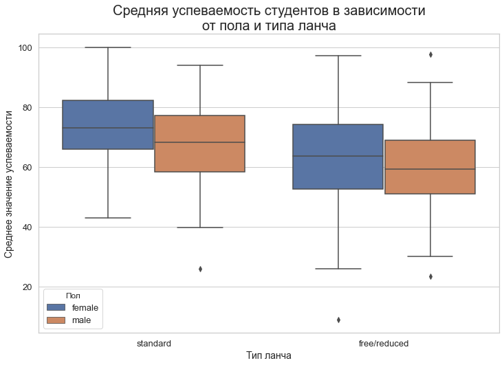

```python
# Построим боксплоты средней успеваемости, разбив по полу студентов и типу ланча

sns.boxplot(x="Lunch", y="Mean_score", hue="Gender", data=whole_students_data)
plt.xlabel("Тип ланча")
plt.ylabel("Среднее значение успеваемости")
plt.title("Средняя успеваемость студентов в зависимости\nот пола и типа ланча")
plt.legend(title="Пол", loc="lower left", fontsize=13);
```

## 5. Распределение оценок

```python
# Зададим функцию для расчета оценки

def calculate_grade(score):
    """
    Функция принимает балл студента (в диапазоне 0 - 100) и переводит его в оценку.
    Оценка возвращается в виде строки

    score: балл студента (от 0 до 100)

    Функция возвращает str
    """
    if score >= 90:
        return "Отлично"
    elif score >= 75:
        return "Хорошо"
    elif score >= 60:
        return "Удовлетворительно"
    return "Незачёт"
```

```python
# Создадим новую колонку
# Рассчитаем оценку, исходя из среднего балла студента

whole_students_data["Grade"] = whole_students_data["Mean_score"].apply(calculate_grade)
whole_students_data.head()
```

|  | Gender | Lunch | Math_score | Reading_score | Writing_score | Mean_score | Grade |
| --- | --- | --- | --- | --- | --- | --- | --- |
| 0 | female | standard | 72 | 72 | 74 | 72.67 | Удовлетворительно |
| 1 | female | standard | 69 | 90 | 88 | 82.33 | Хорошо |
| 2 | female | standard | 90 | 95 | 93 | 92.67 | Отлично |
| 3 | male | free/reduced | 47 | 57 | 44 | 49.33 | Незачёт |
| 4 | male | standard | 76 | 78 | 75 | 76.33 | Хорошо |

```python
# Посчитаем количество полученных оценок

grade_count = (
    whole_students_data.groupby("Grade", as_index=False)
    .agg(Grade_Count=("Grade", "count"))
    .sort_values(by="Grade_Count")
    .reset_index(drop=True)
)

grade_count
```

|  | Grade | Grade_Count |
| --- | --- | --- |
| 0 | Отлично | 31 |
| 1 | Хорошо | 155 |
| 2 | Незачёт | 173 |
| 3 | Удовлетворительно | 237 |

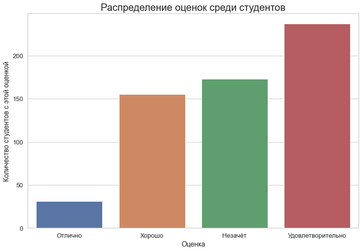

```python
# Для наглядности построим это распределение

sns.barplot(x="Grade", y="Grade_Count", data=grade_count)
plt.xlabel("Оценка")
plt.ylabel("Количество студентов с этой оценкой")
plt.title("Распределение оценок среди студентов");
```